# Análisis Exploratorio de Datos

Camilo Andrés Morales Flores, Rubén Saiz López, Juan José Martínez Aguiló, Mateo Vilar Cano e Isaac Herranz Blasco

2025-03-27

# Lectura de datos y librerias

Vamos a leer las librerias necesarias para seguir con el análisis de datos y las bases sobre las que vamos a trabajar.

```r
library(readxl);
library(dplyr);
library(writexl);
library(knitr);


IE <- read_excel("union_europea_IE.xlsx", col_types = 'text');
PIB <- read_excel("union_europea_PIB.xlsx", col_types = 'text');
```

## Muestra de datos

Se muestran los datos originales sobre los que vamos a trabajar.

Datos PIB original

| DATAFLOW | LAST UPDATE | freq | unit | nace_r2 | na_item | geo | TIME_PERIOD | OBS_VALUE | OBS_FLAG | CONF_STATUS |
| --- | --- | --- | --- | --- | --- | --- | --- | --- | --- | --- |
| ESTAT:NAMA_10_A10(1.0) | 27/02/25 23:00:00 | Annual | Chain linked volumes (2005), million euro | Agriculture, forestry and fishing | Value added, gross | Albania | 2019 | 2086.6 | b | NA |
| ESTAT:NAMA_10_A10(1.0) | 27/02/25 23:00:00 | Annual | Chain linked volumes (2005), million euro | Agriculture, forestry and fishing | Value added, gross | Albania | 2020 | 2124.1 | NA | NA |
| ESTAT:NAMA_10_A10(1.0) | 27/02/25 23:00:00 | Annual | Chain linked volumes (2005), million euro | Agriculture, forestry and fishing | Value added, gross | Albania | 2021 | 2088.3000000000002 | NA | NA |
| ESTAT:NAMA_10_A10(1.0) | 27/02/25 23:00:00 | Annual | Chain linked volumes (2005), million euro | Agriculture, forestry and fishing | Value added, gross | Albania | 2022 | 1987.6 | NA | NA |
| ESTAT:NAMA_10_A10(1.0) | 27/02/25 23:00:00 | Annual | Chain linked volumes (2005), million euro | Agriculture, forestry and fishing | Value added, gross | Albania | 2023 | 1951.3 | p | NA |
| ESTAT:NAMA_10_A10(1.0) | 27/02/25 23:00:00 | Annual | Chain linked volumes (2005), million euro | Agriculture, forestry and fishing | Value added, gross | Austria | 1995 | 2953.8 | NA | NA |

Datos IE original

| DATAFLOW | LAST UPDATE | freq | unit | na_item | geo | TIME_PERIOD | OBS_VALUE | OBS_FLAG | CONF_STATUS |
| --- | --- | --- | --- | --- | --- | --- | --- | --- | --- |
| ESTAT:NAMA_10_EXI(1.0) | 27/02/25 23:00:00 | Annual | Chain linked volumes (2005), million euro | Exports of goods and services | Albania | 2019 | 3678.6 | b | NA |
| ESTAT:NAMA_10_EXI(1.0) | 27/02/25 23:00:00 | Annual | Chain linked volumes (2005), million euro | Exports of goods and services | Albania | 2020 | 2658.7 | NA | NA |
| ESTAT:NAMA_10_EXI(1.0) | 27/02/25 23:00:00 | Annual | Chain linked volumes (2005), million euro | Exports of goods and services | Albania | 2021 | 4043.8 | NA | NA |
| ESTAT:NAMA_10_EXI(1.0) | 27/02/25 23:00:00 | Annual | Chain linked volumes (2005), million euro | Exports of goods and services | Albania | 2022 | 4733 | NA | NA |
| ESTAT:NAMA_10_EXI(1.0) | 27/02/25 23:00:00 | Annual | Chain linked volumes (2005), million euro | Exports of goods and services | Albania | 2023 | 5180.3999999999996 | p | NA |
| ESTAT:NAMA_10_EXI(1.0) | 27/02/25 23:00:00 | Annual | Chain linked volumes (2005), million euro | Exports of goods and services | Austria | 1995 | 63483.8 | NA | NA |

# Análisis de calidad

## Descarte de variables

```r
PIB2 <- PIB[, 4:9];
knitr::kable(head(PIB2), caption= 'Variables empleadas PIB')
```

Variables empleadas PIB

| unit | nace_r2 | na_item | geo | TIME_PERIOD | OBS_VALUE |
| --- | --- | --- | --- | --- | --- |
| Chain linked volumes (2005), million euro | Agriculture, forestry and fishing | Value added, gross | Albania | 2019 | 2086.6 |
| Chain linked volumes (2005), million euro | Agriculture, forestry and fishing | Value added, gross | Albania | 2020 | 2124.1 |
| Chain linked volumes (2005), million euro | Agriculture, forestry and fishing | Value added, gross | Albania | 2021 | 2088.3000000000002 |
| Chain linked volumes (2005), million euro | Agriculture, forestry and fishing | Value added, gross | Albania | 2022 | 1987.6 |
| Chain linked volumes (2005), million euro | Agriculture, forestry and fishing | Value added, gross | Albania | 2023 | 1951.3 |
| Chain linked volumes (2005), million euro | Agriculture, forestry and fishing | Value added, gross | Austria | 1995 | 2953.8 |

```r
IE2 <- IE[, 4:8];
knitr::kable(head(IE2), caption= 'Variables empleadas IE')
```

Variables empleadas IE

| unit | na_item | geo | TIME_PERIOD | OBS_VALUE |
| --- | --- | --- | --- | --- |
| Chain linked volumes (2005), million euro | Exports of goods and services | Albania | 2019 | 3678.6 |
| Chain linked volumes (2005), million euro | Exports of goods and services | Albania | 2020 | 2658.7 |
| Chain linked volumes (2005), million euro | Exports of goods and services | Albania | 2021 | 4043.8 |
| Chain linked volumes (2005), million euro | Exports of goods and services | Albania | 2022 | 4733 |
| Chain linked volumes (2005), million euro | Exports of goods and services | Albania | 2023 | 5180.3999999999996 |
| Chain linked volumes (2005), million euro | Exports of goods and services | Austria | 1995 | 63483.8 |

## Tipo de variables

Describimos de qué tipo son las variables de cada base de datos

```r
descIE = data.frame("variable" = colnames(IE2),
                    "tipo" = c('text', rep('categorical',2), rep("numerical", 2)),
                    stringsAsFactors = FALSE);
descPIB = data.frame("variable" = colnames(PIB2),
                    "tipo" = c('text','categorical','text','categorical', rep("numerical", 2)),
                    stringsAsFactors = FALSE);
```

Lo mostramos en estas tablas:

Variables IE

| variable | tipo |
| --- | --- |
| unit | text |
| na_item | categorical |
| geo | categorical |
| TIME_PERIOD | numerical |
| OBS_VALUE | numerical |

Variables PIB

| variable | tipo |
| --- | --- |
| unit | text |
| nace_r2 | categorical |
| na_item | text |
| geo | categorical |
| TIME_PERIOD | numerical |
| OBS_VALUE | numerical |

# Análisis Exploratorio

## Distribución de valores

Se analizan las variables numéricas de ambas bases de datos con las variables ya seleccionadas.( Se empieza con el resumen básico que muestra la distribución de los datos (media, mediana, cuartiles…)  
Variables numéricas de IE:

```r
## Numericas
IEnumeric_columns <- descIE$variable[descIE$tipo == 'numerical']
IE2[, IEnumeric_columns] <- lapply(IE2[, IEnumeric_columns], as.numeric)
knitr::kable(summary(IE2[, IEnumeric_columns]), caption= 'Resumen Variables Numéricas IE')
```

Resumen Variables Numéricas IE

|  | TIME_PERIOD | OBS_VALUE |
| --- | --- | --- |
|  | Min. :1975 | Min. : -16 |
|  | 1st Qu.:2006 | 1st Qu.: 9160 |
|  | Median :2013 | Median : 38143 |
|  | Mean :2011 | Mean : 390846 |
|  | 3rd Qu.:2018 | 3rd Qu.: 195431 |
|  | Max. :2024 | Max. :62382147 |
|  | NA | NA’s :320 |

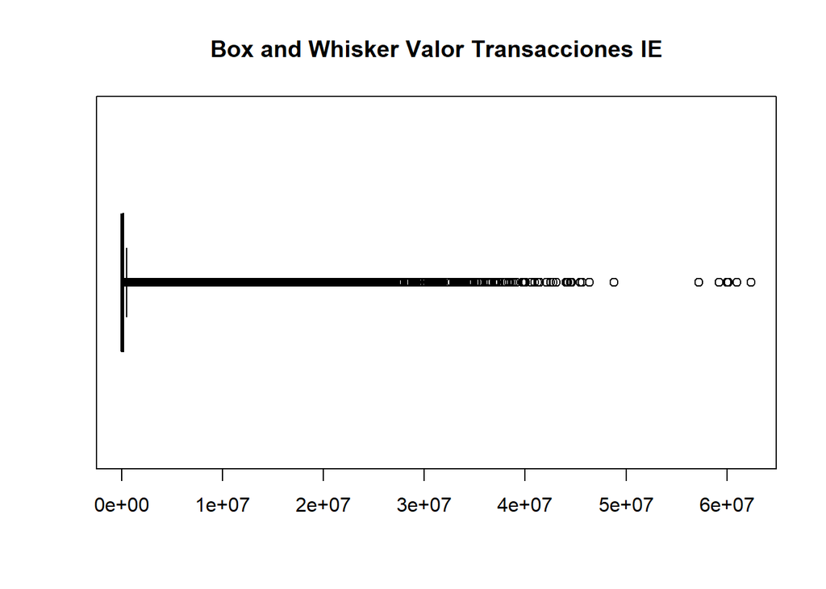

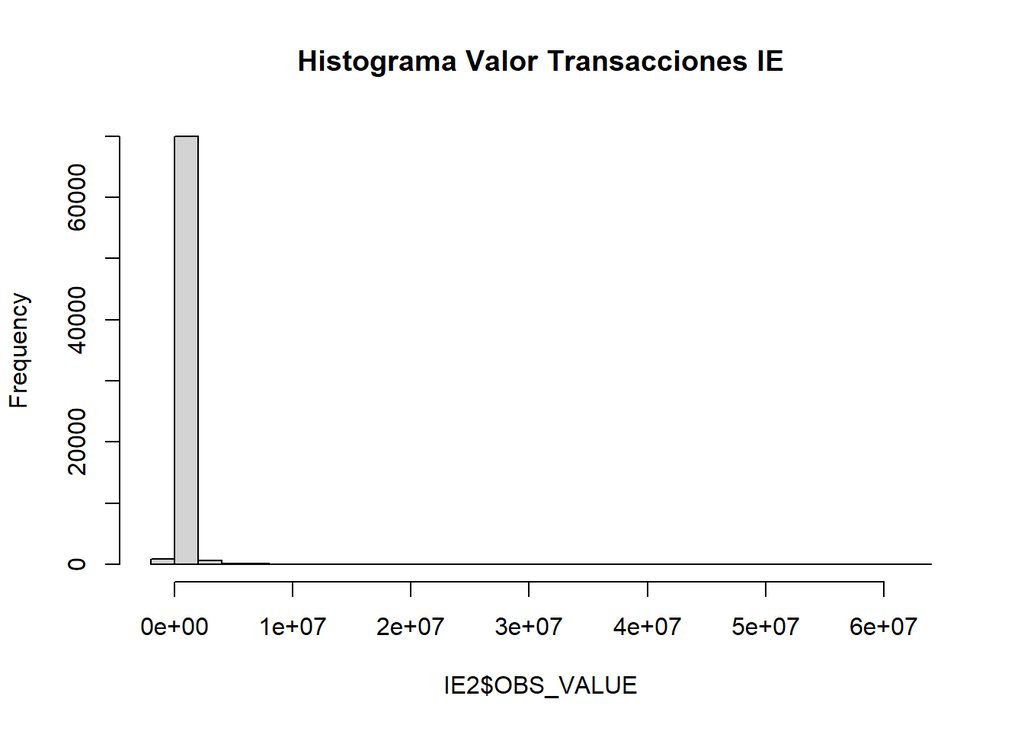

Analizando las gráficas se confirman las observaciones.

Variables Numéricas de PIB:

```r
## Numericas

PIBnumeric_columns <- descPIB$variable[descPIB$tipo == 'numerical']
PIB2[, PIBnumeric_columns] <- lapply(PIB2[, PIBnumeric_columns], as.numeric)
knitr::kable(summary(PIB2[, PIBnumeric_columns]), caption= 'Resumen Variables Numéricas PIB')
```

Resumen Variables Numéricas PIB

|  | TIME_PERIOD | OBS_VALUE |
| --- | --- | --- |
|  | Min. :1975 | Min. : -939 |
|  | 1st Qu.:2001 | 1st Qu.: 7 |
|  | Median :2009 | Median : 100 |
|  | Mean :2008 | Mean : 99971 |
|  | 3rd Qu.:2016 | 3rd Qu.: 5862 |
|  | Max. :2024 | Max. :64951080 |
|  | NA | NA’s :6309 |

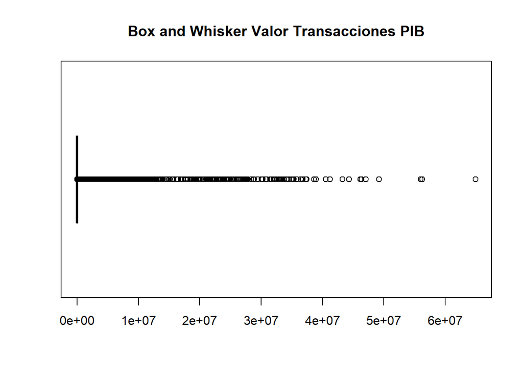

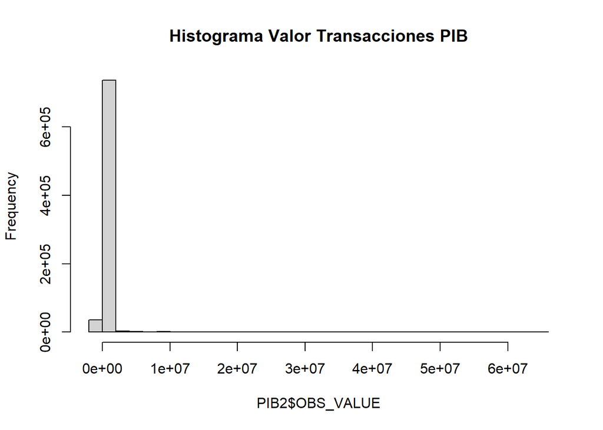

Se confirman las observaciones con ambas gráficas que muestran una mayor frecuencia de los datos cuando las transacciones son de menor valor.

```r
PIB3 <- PIB2[PIB2$unit %in% c('Current prices, million euro', 'Percentage of gross domestic product(GDP)','Percentage of total'),]

PIB3 <- PIB3[!PIB3$geo %in% c('Euro area - 12 countries (2001-2006)', 'Euro area - 19 countries (2015-2022)', 'Euro area - 20 countries (from 2023)','European Union - 27 countries (from 2020)', 'Euro area (EA11-1999, EA12-2001, EA13-2007, EA15-208, EA16-2009, EA17-2011, EA18-2014, EA19-2015, EA15-2023'),]

PIB3 <- PIB3[!PIB3$nace_r2 == 'Total - all NACE activities',]

IE3 <- IE2[IE2$unit=='Current prices, million euro', ]

IE3 <- IE3[IE3$na_item %in% c('Exports of goods and services', 'Imports of goods and services'), ]
```

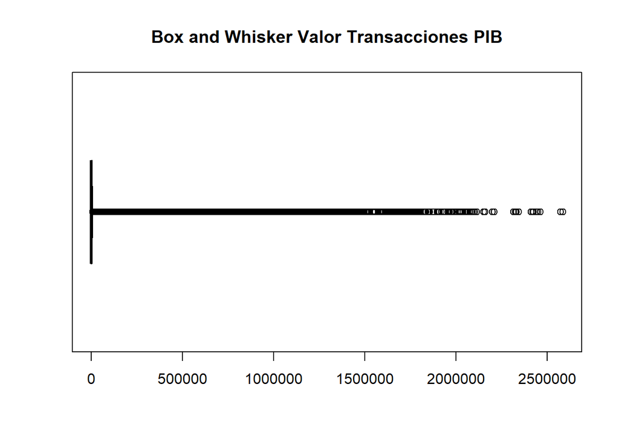

```r
PIB3$OBS_VALUE <- as.numeric(PIB3$OBS_VALUE)
p2 <- boxplot(PIB3[,"OBS_VALUE"], horizontal = TRUE)
title('Box and Whisker Valor Transacciones PIB')
```

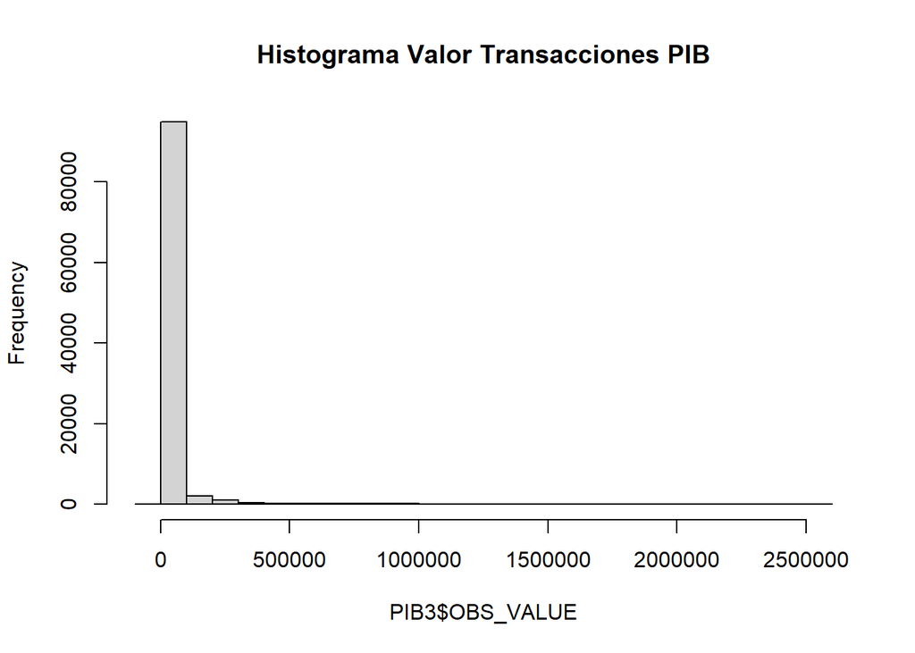

```r
p1 <- hist(PIB3$OBS_VALUE, nclass= 30, main= '')
title('Histograma Valor Transacciones PIB')
```

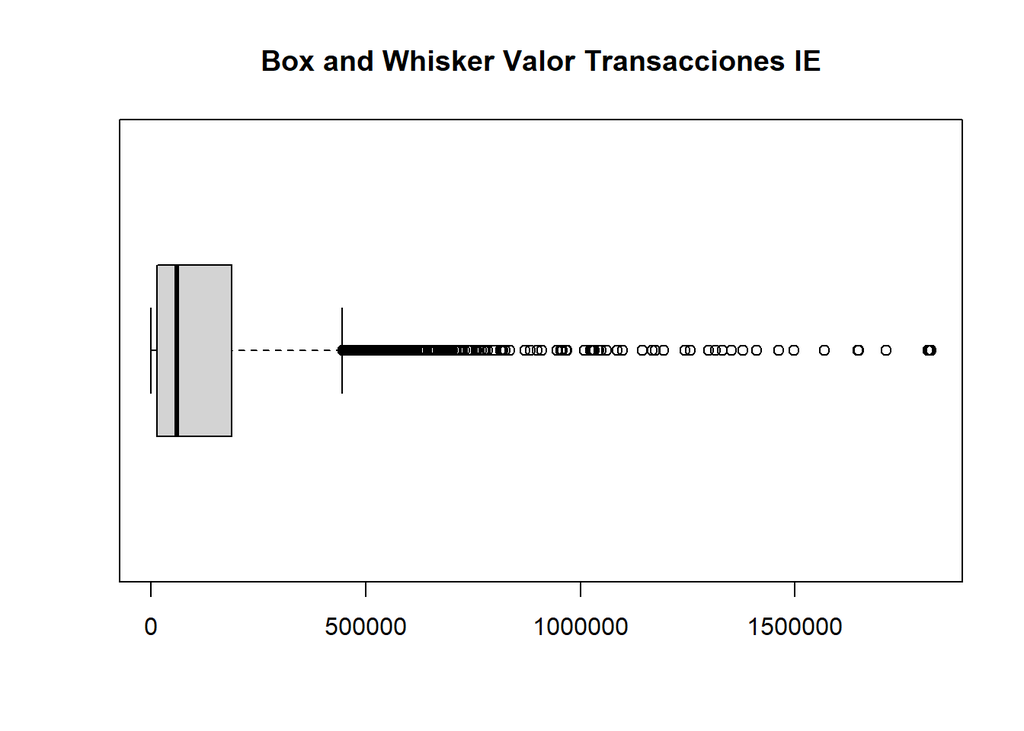

```r
IE3$OBS_VALUE <- as.numeric(IE3$OBS_VALUE)
boxplot(IE3[,"OBS_VALUE"], horizontal = TRUE)
title('Box and Whisker Valor Transacciones IE')
```

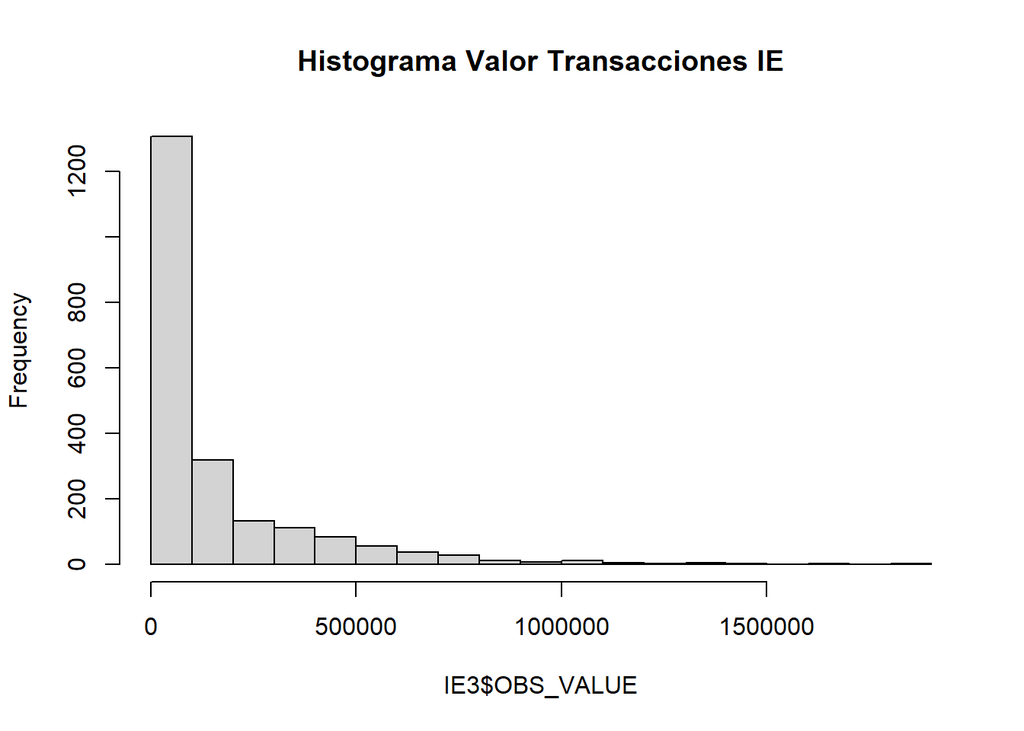

```r
hist(IE3$OBS_VALUE, nclass = 25, main = '')
title('Histograma Valor Transacciones IE')
```

## Valores Faltantes

Vamos a observar los valores faltantes de la base de datos IE por cada variable tanto en cantidad como en porcentaje sobre el total.

Valores faltantes IE

|  | Variable | numNA | percNA |
| --- | --- | --- | --- |
| OBS_VALUE | OBS_VALUE | 320 | 0.44 |

Observamos que solo hay valores faltantes en la variable obs_value, en concreto 320, que es un 0.44% sobre el total. Como la variable que queremos estudiar es esta, no nos interesa mantener las observaciones sobre las cuales no tenemos esa información, más adelante tras analizar la base de datos PIB, eliminaremos aquellas observaciones en las que no se tenga información en la variable OBS_VALUE.  
Ahora vamos a observar los valores faltantes de la base de datos PIB:

```r
# Calcular el número de valores NA por columna
numNA <- apply(PIB2, 2, function(x) sum(is.na(x)))

# Calcular el porcentaje de valores NA por columna
percNA <- round(100 * apply(PIB2, 2, function(x) mean(is.na(x))), 2)

# Crear un data frame con los resultados
tablaNA <- data.frame("Variable" = names(PIB2), "numNA" = numNA, "percNA" = percNA)

# Filtrar solo las columnas con valores faltantes
tablaNA_faltantes2 <- tablaNA[tablaNA$numNA > 0, ]

knitr::kable(tablaNA_faltantes2, caption= 'Valores Faltantes PIB')
```

Valores Faltantes PIB

|  | Variable | numNA | percNA |
| --- | --- | --- | --- |
| OBS_VALUE | OBS_VALUE | 6309 | 0.81 |

En esta base de datos encontramos 6309 casos faltantes únicamente en la variable OBS_VALUE, aunque pueda parecer una cantidad excesiva es únicamente el 0.81 % del total, como se repite la situación en la que es esta la variable que queremos estudiar, vamos a eliminar aquellas observaciones en las que no se tenga esta información.

## Eliminación Valores Faltantes

Partiendo de que no nos interesan aquellas filas en las que falte aparezcan valores faltantes, debido a que la carencia de información en alguna de todas las variables, la observación no nos sirve. Se eliminan todas las filas en las que falte cualquier tipo de información.

```r
PIB3 <- PIB3[!is.na(PIB3$OBS_VALUE),]
IE3 <- IE3[!is.na(IE3$OBS_VALUE),]
```

# Indices de Libertad

## Lecutra de datos

Base de datos independiente de las anteriores que añadiremos al estudio para correlacionar las políticas del país con su rendimiento económico. A esta base de datos le sustituiremos los valores nulos por 0, no eliminaremos información de paises por los valores faltantes.

Se muestra la base de datos original:

```
## Hay 184 paises inicialmente
```

Muestra Índice Libertad

| Country | Region | Overall Score | Property Rights | Government Integrity | Judicial Effectiveness | Tax Burden | Government Spending | Fiscal Health | Business Freedom | Labor Freedom | Monetary Freedom | Trade Freedom | Investment Freedom | Financial Freedom |
| --- | --- | --- | --- | --- | --- | --- | --- | --- | --- | --- | --- | --- | --- | --- |
| Singapore | Asia-Pacific | 83.5 | 94.2 | 88.3 | 58.3 | 90.7 | 89.2 | 76.0 | 86.9 | 77.3 | 76.3 | 95.0 | 90 | 80 |
| Switzerland | Europe | 83.0 | 94.2 | 91.3 | 98.1 | 70.4 | 64.6 | 95.7 | 89.3 | 60.7 | 80.8 | 86.4 | 85 | 80 |
| Ireland | Europe | 82.6 | 93.5 | 83.4 | 94.3 | 78.0 | 82.4 | 91.7 | 91.3 | 62.8 | 74.5 | 79.2 | 90 | 70 |
| Taiwan | Asia-Pacific | 80.0 | 82.2 | 73.4 | 94.0 | 79.2 | 90.5 | 90.3 | 84.9 | 69.1 | 80.1 | 86.4 | 70 | 60 |
| Luxembourg | Europe | 79.2 | 96.9 | 84.9 | 95.8 | 64.6 | 40.6 | 97.6 | 89.5 | 57.7 | 69.1 | 79.2 | 95 | 80 |
| Denmark | Europe | 77.8 | 98.6 | 97.4 | 89.6 | 41.8 | 26.8 | 98.2 | 92.7 | 64.9 | 74.3 | 79.2 | 90 | 80 |

## Tratado valores faltantes

Se añaden 0 a los valores faltantes, y mostramos la cabecera del resultado.

```
## Hay 0 paises con valores faltantes
```

| Country | Region | Overall Score | Property Rights | Government Integrity | Judicial Effectiveness | Tax Burden | Government Spending | Fiscal Health | Business Freedom | Labor Freedom | Monetary Freedom | Trade Freedom | Investment Freedom | Financial Freedom |
| --- | --- | --- | --- | --- | --- | --- | --- | --- | --- | --- | --- | --- | --- | --- |
| Singapore | Asia-Pacific | 83.5 | 94.2 | 88.3 | 58.3 | 90.7 | 89.2 | 76.0 | 86.9 | 77.3 | 76.3 | 95.0 | 90 | 80 |
| Switzerland | Europe | 83.0 | 94.2 | 91.3 | 98.1 | 70.4 | 64.6 | 95.7 | 89.3 | 60.7 | 80.8 | 86.4 | 85 | 80 |
| Ireland | Europe | 82.6 | 93.5 | 83.4 | 94.3 | 78.0 | 82.4 | 91.7 | 91.3 | 62.8 | 74.5 | 79.2 | 90 | 70 |
| Taiwan | Asia-Pacific | 80.0 | 82.2 | 73.4 | 94.0 | 79.2 | 90.5 | 90.3 | 84.9 | 69.1 | 80.1 | 86.4 | 70 | 60 |
| Luxembourg | Europe | 79.2 | 96.9 | 84.9 | 95.8 | 64.6 | 40.6 | 97.6 | 89.5 | 57.7 | 69.1 | 79.2 | 95 | 80 |
| Denmark | Europe | 77.8 | 98.6 | 97.4 | 89.6 | 41.8 | 26.8 | 98.2 | 92.7 | 64.9 | 74.3 | 79.2 | 90 | 80 |

## Exportación Bases de Datos

Antes de seguir con el estudio, se guarda la base de datos modificada con la que se sigue en formato xlsx.

```r
writexl::write_xlsx(Indices3, 'Indices_libertad2.xlsx')
```

# Commodities

Se vuelve a cambiar de base de datos y ahora trataremos la que muestra los datos de exportación e importación de cada país. La utilizaremos para comprobar si el índice de libertad, y el PIB tiene relación con el nivel de importaciones y exportaciones.

## Lectura de Bases de datos

Se empieza con la lectura de las bases de datos.

```
## [1] "EXPORT" "IMPORT"
```

## Tratado de variables

Se empieza a borrar aquellas variables que tenemos claro que queremos descartar, que son: ‘comm_code’, ‘quantity_name’, ‘quantity’ y ‘flow’.

```r
# Variables a quitar
variablesQuitar <- c("comm_code", "quantity_name", "quantity","flow");

# Aplicar la eliminación de variables a cada dataframe en la lista
lista_dataframes_filtrada <- lapply(lista_dataframes, function(df){df[, !(names(df) %in% variablesQuitar)]});

COMEXP = lista_dataframes_filtrada[[1]]
COMIMP = lista_dataframes_filtrada[[2]]
```

## Filtrado de casos

```r
# Filtrar COMEXP
COMEXP <- COMEXP[!(COMEXP$commodity == "ALL COMMODITIES" & COMEXP$country_or_area == "EU-28"), ];

COMIMP <- COMIMP[!(COMIMP$commodity == "ALL COMMODITIES" & COMIMP$country_or_area == "EU-28"), ];

head(COMEXP)
```

```
## # A tibble: 6 × 6
##   country_or_area year  commodity                   trade_usd weight_kg category
##   <chr>           <chr> <chr>                       <chr>     <chr>     <chr>
## 1 Algeria         2016  Horses, live pure-bred bre… 126137    4800      01_live…
## 2 Algeria         2016  Poultry, live except domes… 263       40        01_live…
## 3 Algeria         2015  Horses, live pure-bred bre… 86724     2400      01_live…
## 4 Algeria         2014  Horses, live pure-bred bre… 20466     3100      01_live…
## 5 Algeria         2013  Horses, live pure-bred bre… 14163     300       01_live…
## 6 Algeria         2012  Horses, live pure-bred bre… 71776     500       01_live…
```

```r
head(COMIMP)
```

```
## # A tibble: 6 × 6
##   country_or_area year  commodity                   trade_usd weight_kg category
##   <chr>           <chr> <chr>                       <chr>     <chr>     <chr>
## 1 Algeria         2016  Horses, live pure-bred bre… 978230    84260     01_live…
## 2 Algeria         2016  Horses, live except pure-b… 96656     19430     01_live…
## 3 Algeria         2016  Bovine animals, live, exce… 85118623  25486676  01_live…
## 4 Algeria         2016  Fowls, live domestic < 185… 23609477  257096    01_live…
## 5 Algeria         2016  Poultry, live except domes… 3792216   42470     01_live…
## 6 Algeria         2016  Animals, live, except farm… 112005    5886      01_live…
```